# tobacco

[figure not shown]

M2.859 · Visualización de datos aula 2

2020-2 · Máster universitario en Ciencia de datos (Data science)

Estudios de Informática, Multimedia y Telecomunicación

Nombre: Adonis González Godoy

# EDA Dataset Tobacco

## 1. Título

**Medidas de control sobre el tabaquismo aplicadas en diferentes países y regiones**

## 2. Descripción de los datos seleccionados

El dataset ha sido seleccionado de la página oficial de la Organización Mundial de la Salud. La información se refiere al Tabaquismo en el año 2016 y hace un seguimiento de la situación en diferentes países y regiones que han aplicado políticas de control del tabaco que van desde advertencias gráficas y prohibiciones de publicidades hasta zonas de no fumadores.

Los datos se han recopilado para intentar mejorar el bienestar de las personas y reducir los riegos de la salud asociados al consumo de tabaco, contribuyendo así a mejorar la salud de la población. El tabaquismo es un trastorno crónico en que la persona presenta una adicción física como psicológica al consumo de tabaco. El consumo de tabaco es uno de los principales factores de riesgo carcinógeno y otras enfermedades pulmonares. Además de ser altamente adictivo, la nicótica es la droga responsable en primer lugar de la adicción de una persona, esta adicción es semejase a la adicción producida por el uso de drogas como la heroína y la cocaína. No se ha tenido en cuanto la perspectiva de género ya que el colectivo es específico.

Link de la fuente del dataset: https://www.who.int/tobacco/global_report/2013/full_dataset/en/

## 3. Los datos

Cargamos las librerias necesarias.

```python
import matplotlib.pyplot as plt
from seaborn import boxplot
import seaborn as sns
import pandas as pd
import numpy as np
import pycountry
import os

import warnings
warnings.filterwarnings("ignore")
```

Cargamos el conjunto de datos.

```python
ROOT_DIR = os.path.abspath("../")
DATA_DIR = os.path.join(ROOT_DIR, "data")
data_file = os.path.join(DATA_DIR, "RGTE17_CoreDataSet.xls")
```

```python
data_xlsx = pd.ExcelFile(data_file)
```

El conjunto de datos lo pasaremos a pandas dataframe

```python
sheet_names = data_xlsx.sheet_names
df = data_xlsx.parse(sheet_names[0])
```

```python
df.head(10)
```

|  | Region | Country | ISO_3_Country_Code | M_Group_16 | P_Group_16 | O_Group_16 | W_Group_16 | W-MM_Group_16 | E_Group_16 | R_Group_16 | ... | R_Other_estimate_16 | R_total_tax_estimate_16 | R_excise_incr_16 | R_afford_gdp_%_16 | NTCP_govt_obj_16 | NTCP_agcy_16 | NTCP_FTE_16 | NTCP_govt_exp_16 | NTCP_curr_16 | NTCP_budget_year_16 |
| --- | --- | --- | --- | --- | --- | --- | --- | --- | --- | --- | --- | --- | --- | --- | --- | --- | --- | --- | --- | --- | --- |
| 0 | AFR | Algeria | DZA | 2 | 3 | 3 | 2 | 1 | 4 | 3 | ... | 0 | 0.4306 | Yes | 0.0313 | Yes | Yes | 2 | 324753406 | DZD | 2010 |
| 1 | AFR | Angola | AGO | 1 | 3 | 3 | 2 | 2 | 2 | 1 | ... | . . . | . . . | No | . . . | Yes | Yes | . . . | . . . | . . . | . . . |
| 2 | AFR | Benin | BEN | 2 | 4 | 4 | 3 | 1 | 4 | 2 | ... | 0.0069 | 0.0642 | No | 0.1094 | Yes | Yes | 3 | . . . | . . . | . . . |
| 3 | AFR | Botswana | BWA | 2 | 2 | 3 | 2 | 2 | 4 | 3 | ... | 0 | 0.4972 | Yes | 0.0439 | Yes | Yes | 3 | . . . | . . . | . . . |
| 4 | AFR | Burkina Faso | BFA | 2 | 5 | 3 | 5 | 2 | 4 | 3 | ... | 0 | 0.3481 | Yes | 0.1698 | Yes | Yes | 6 | 5400000 | XOF | 2005 |
| 5 | AFR | Burundi | BDI | 1 | 2 | 2 | 2 | 1 | 2 | 3 | ... | 0 | 0.4275 | No | 0.2973 | Yes | Yes | 13 | 12500000 | BIF | 2012 |
| 6 | AFR | Cabo Verde | CPV | 4 | 2 | 4 | 2 | 2 | 4 | 2 | ... | 0.0031 | 0.2384 | No | 0.0587 | Yes | Yes | 1.5 | 1571625 | CVE | 2005 |
| 7 | AFR | Cameroon | CMR | 3 | 3 | 4 | 4 | 5 | 4 | 2 | ... | 0.0157 | 0.2131 | No | 0.0681 | Yes | Yes | 9 | 25000000 | XAF | 2008 |
| 8 | AFR | Central African Republic | CAF | 1 | 2 | 3 | 2 | 1 | 2 | 1 | ... | . . . | . . . | No | . . . | Yes | Yes | 2 | 8400000 | XAF | 2005 |
| 9 | AFR | Chad | TCD | 1 | 5 | 3 | 5 | 1 | 5 | 3 | ... | 0.0283 | 0.3447 | Yes | 0.1485 | Yes | Yes | 10 | 122500000 | FCFA | 2015 |

10 rows × 173 columns

### Descripción de variables

| Campo | Descripción |
| --- | --- |
| Contry | - Campo de tipo String que se refiere los diferentes países en los que se han recogido los datos |
| Region | - Campo de tipo String que se refiere a Region, contienes las diferentes regiones donde se han recogido los datos |
| E_Group_16 | - Variable categórica que oontiene las restricciones que tienen respecto al tabaco en la televisión, la radio y los medios impresos nacionales |
| R_Price_mp_usd_16 | - Esta variable contiene el precio de una cajetilla de 20 cigarrillos de la marca más vendida en usd a tipos de cambio oficiales |
| R_Total_tax_stimate | - Este campo contien el impuesto en porcentaje % del precio de la marca más vendida |
| P_Group_16 | - Tipos de restricción que tienen con respecto a los lugares públicos libres de humo |

### Exploración de los datos

```python
for key,value in df.dtypes.iteritems():
        print(key," -->",value)
```

```
Region  --> object
Country  --> object
ISO_3_Country_Code  --> object
M_Group_16  --> int64
P_Group_16  --> int64
O_Group_16  --> int64
W_Group_16  --> int64
W-MM_Group_16  --> int64
E_Group_16  --> int64
R_Group_16  --> object
P1_healthcare_16  --> object
P2_education_16  --> object
P3_universities_16  --> object
P4_govt_16  --> object
P5_indoor_off_16  --> object
P6_restaurants_16  --> object
P7_pubs_16  --> object
P8_pub_transp_16  --> object
P9_all_other_16  --> object
P_count_places_sf_16  --> int64
P11_fines_any_16  --> object
P12_fines_establishment_16  --> object
P13_fines_smoker_16  --> object
P14_funds_for_enforce_16  --> object
P15_complaints_16  --> object
P10_subnat_auth_exists_16  --> object
P16_subnat_complete_bans_exist  --> object
O_Quitline_16  --> object
O_Avail_hlth_clin_16  --> object
O_Avail_hosp_16  --> object
O_Avail_off_hlth_prof_16  --> object
O_Avail_community_16  --> object
O_Avail_other_16  --> object
O_Ins_hlth clin_16  --> object
O_Ins_hosp_16  --> object
O_Ins_off_hlth_prof_16  --> object
O_Ins_community_16  --> object
O_Ins_other_16  --> object
O_NRT_sold_16  --> object
O_NRT_where_16  --> object
```

[output cut: 118 more lines]

```
R_Price_mp_usd_16  --> object
R_Sp_excise_estimate_16  --> object
R_Ad_val_estimate_16  --> object
R_imp_duty_estimate_16  --> object
R_VAT_estimate_16  --> object
R_Other_estimate_16  --> object
R_total_tax_estimate_16  --> object
R_excise_incr_16  --> object
R_afford_gdp_%_16  --> object
NTCP_govt_obj_16  --> object
NTCP_agcy_16  --> object
NTCP_FTE_16  --> object
NTCP_govt_exp_16  --> object
NTCP_curr_16  --> object
NTCP_budget_year_16  --> object
```

Como se puede observar la mayoría de datos son de tipo object, por lo general las columnas con tipo de datos object son de tipo String.

Se procede a transformar las variables relevantes para análisis.

La variable `NTCP_govt_exp_16` contiene el presupuesto nacional global para las actividades de control del tabaco (último año disponible): en la moneda indicada

La variable `R_Price_mp_estimate_16` contiene el precio de un paquete de 20 cigarrillos de la marca más vendida en la moneda declarada

```python
df["R_Price_mp_estimate_16"] = pd.to_numeric(df["R_Price_mp_estimate_16"], errors='coerce')
df["R_Price_mp_estimate_16"]
```

```
0        135.00
1           NaN
2        500.00
3         33.33
4        650.00
         ...
190       32.00
191       12.00
192        3.50
193      720.00
194    20000.00
Name: R_Price_mp_estimate_16, Length: 195, dtype: float64
```

La variable `R_Price_mp_usd_16` contiene el precio de un paquete de 20 cigarrillos de la marca más vendida en usd al cambio oficial.

```python
df["R_Price_mp_usd_16"] = pd.to_numeric(df["R_Price_mp_usd_16"], errors='coerce')
df["R_Price_mp_usd_16"]
```

```
0      1.22
1       NaN
2      0.85
3      3.12
4      1.10
       ...
190    4.04
191    5.43
192    2.63
193    6.60
194    0.91
Name: R_Price_mp_usd_16, Length: 195, dtype: float64
```

```python
df.shape
```

```
(195, 173)
```

Como se puede ver la dimensión del dataset es de **195 filas x 173** columnas. Es un dataset extenso y disponible para aplicar diferentes técnicas de análisis.

A continuación se analizará la estructura y resumen de datos, de esta forma se entenderá mejor el dataset.

```python
df.describe()
```

|  | M_Group_16 | P_Group_16 | O_Group_16 | W_Group_16 | W-MM_Group_16 | E_Group_16 | P_count_places_sf_16 | R_Price_mp_estimate_16 | R_Price_mp_usd_16 |
| --- | --- | --- | --- | --- | --- | --- | --- | --- | --- |
| count | 195.000000 | 195.000000 | 195.000000 | 195.000000 | 195.000000 | 195.000000 | 195.000000 | 188.000000 | 187.000000 |
| mean | 2.800000 | 3.276923 | 3.774359 | 3.702564 | 2.687179 | 3.661538 | 4.051282 | 942.409096 | 3.381176 |
| std | 1.142434 | 1.294409 | 0.793244 | 1.245091 | 1.450059 | 1.064085 | 3.174875 | 3155.579619 | 3.012088 |
| min | 1.000000 | 1.000000 | 1.000000 | 2.000000 | 1.000000 | 2.000000 | 0.000000 | 0.750000 | 0.270000 |
| 25% | 2.000000 | 2.000000 | 3.000000 | 2.000000 | 2.000000 | 2.000000 | 0.500000 | 6.937500 | 1.210000 |
| 50% | 3.000000 | 3.000000 | 4.000000 | 4.000000 | 2.000000 | 4.000000 | 4.000000 | 32.500000 | 2.480000 |
| 75% | 4.000000 | 5.000000 | 4.000000 | 5.000000 | 4.000000 | 4.000000 | 8.000000 | 455.000000 | 4.465000 |
| max | 4.000000 | 5.000000 | 5.000000 | 5.000000 | 5.000000 | 5.000000 | 8.000000 | 21666.670000 | 15.800000 |

Miraremos si el dataset contiene campos con valores nulos.

```python
for key,value in df.isnull().sum().iteritems():
    if value > 0:
        print(key," -->",value)
```

```
P10_subnat_auth_exists_16  --> 9
E20_subnational_exists_16  --> 8
R_Price_mp_estimate_16  --> 7
R_Price_mp_usd_16  --> 8
NTCP_curr_16  --> 1
```

```python
print(df.isnull().values.sum())
print(df.isna().values.sum())
```

```
33
33
```

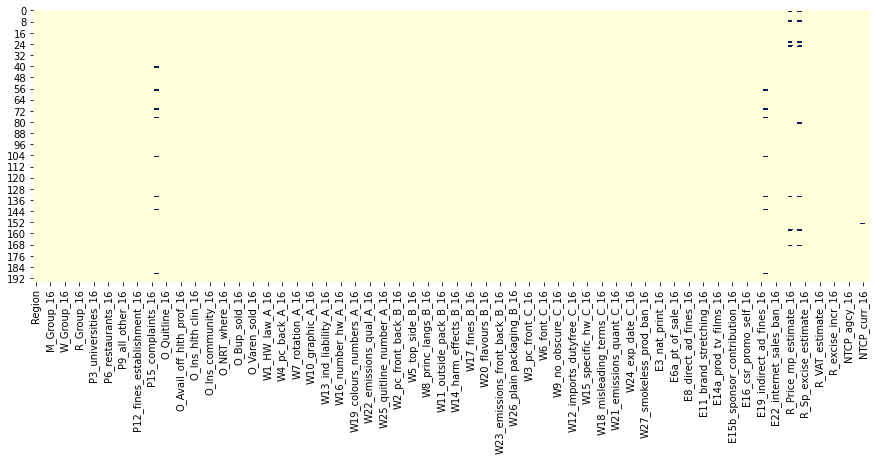

```python
fig, ax = plt.subplots(figsize=(15,5))
sns.heatmap(df.isnull(), cbar=False, vmin=0, vmax=0.7, cmap="YlGnBu", ax=ax)
```

Printamos algunas variables, aunque los gráficos se realizarán con tableu.

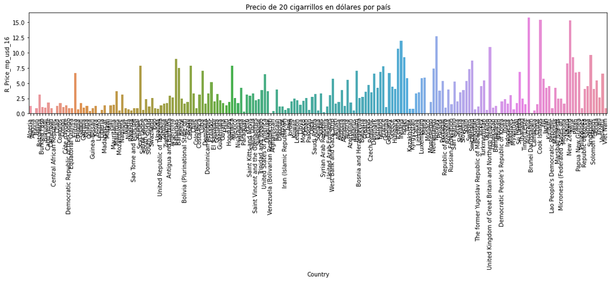

```python
plt.figure(figsize=(15,7))
sns.barplot(x="Country", y="R_Price_mp_usd_16", ci=None, data=df)
plt.title("Precio de 20 cigarrillos en dólares por país")
plt.xticks(rotation=90)
plt.tight_layout()
```

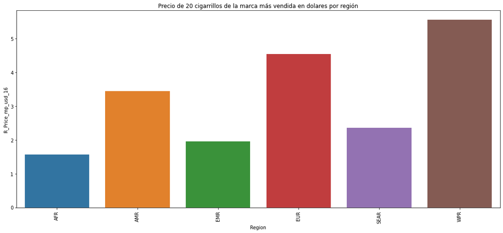

```python
plt.figure(figsize=(15,7))
sns.barplot(x="Region", y="R_Price_mp_usd_16", ci=None, data=df)
plt.title("Precio de 20 cigarrillos de la marca más vendida en dolares por región")
plt.xticks(rotation=90)
plt.tight_layout()
```